# ppol670-assignment04

Theodore Landsman

9/25/2020

## Reshaping the Data

In order to make the first plot, an alluvial plot based on Paul Butler’s work with this data, we first need to reshape the data so that we have an effective vote variable. This variable signifies who a persons’ vote would have counted for in a contest between the two top candidates.

In order to make our ideal point plots, we also need a version of the ranking data reshaped into preference form. This is not a very tidyverse way of doing it, but I found that the easiest way to reshape the data to get my head around was a set of nested for loops.

```r
library(ggalluvial)
library(ggplot2)

# Fill variable by row and set of rankings.
for (i in 1:length(wyoming$Serial)) {
  wyoming$Biden[i] <- match(1, wyoming[i,6:10], NULL)
  wyoming$Steyer[i] <- match(3, wyoming[i,6:10], NULL)
  wyoming$Sanders[i] <- match(4, wyoming[i,6:10], NULL)
  wyoming$Klobuchar[i] <- match(5, wyoming[i,6:10], NULL)
  wyoming$Gabbard[i] <- match(7, wyoming[i,6:10], NULL)
  wyoming$Warren[i] <- match(8, wyoming[i,6:10], NULL)
  wyoming$Bloomberg[i] <- match(9, wyoming[i,6:10], NULL)
  wyoming$Buttgieg[i] <- match(11, wyoming[i,6:10], NULL)


  for (n in 1:5) {
    if (wyoming[i,n+5]=="1") {
      wyoming$e_vote[i] <- 1
      break
    } else if (wyoming[i,n+5] =="4") {
      wyoming$e_vote[i] <- 4
      break
    }
    }
}
```

In order to create an alluvial plot of vote transfers, we then need to aggregate the data by combinations of 1st round vote and effective vote so that ggalluvial can construct the set of alluvium and nodes that make the plot.

```r
# Summarize by 1st preference and effective vote
wyoming$e_vote<-as.character(wyoming$e_vote)
wyoming_freq<-wyoming %>%
  group_by(`1st`,e_vote) %>%
  summarize(Freq = n()) %>%
  arrange(desc(Freq))
```

## Alluvial plot with first preference and effective vote

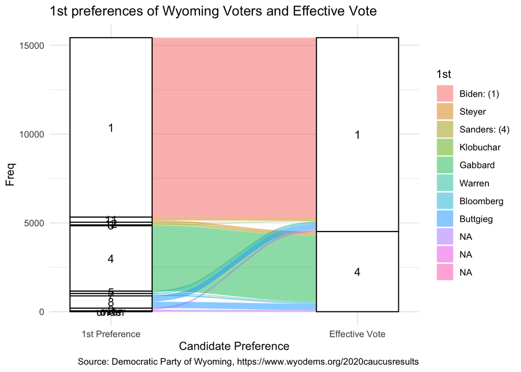

```r
vote_al <- ggplot(data = wyoming_freq,
       aes(axis1 = `1st`,
           axis2 = e_vote,
           y = Freq)) +
  scale_x_discrete(limits = c("1st Preference", "Effective Vote"),
                   expand = c(.2, .05)) +
  xlab("Candidate Preference") +
  geom_alluvium(aes(fill= `1st`)) +
  geom_stratum() +
  geom_text(stat = "stratum", aes(label = after_stat(stratum))) +
  theme_minimal() +
  labs(title= "1st preferences of Wyoming Voters and Effective Vote",
       caption = "Source: Democratic Party of Wyoming, https://www.wyodems.org/2020caucusresults") +
  scale_fill_discrete(labels = c("Biden: (1)",
                                 "Steyer",
                                 "Sanders: (4)",
                                 "Klobuchar",
                                 "Gabbard",
                                 "Warren",
                                 "Bloomberg",
                                 "Buttgieg",
                                  "NA"))
vote_al
```

As a first plot, this is not off to a great start. I had worked with ggalluvial before, but forgotten some of the specifications for stratum renaming and spacing.

## Looking for a latent variable: Ideal Point Estimation

```r
library(smacof)
w_matrix <- wyoming[,11:18]
# There's an error happening where even though the function should handle
# Missing preferences, its crashing if at least one column isn't full, dropping
# observations without a full Biden column  (ie people who put Biden as a choice
# somewhere on their ballot) preserves as much data as possible.
#
w_matrix <- filter(w_matrix,!is.na(Biden))
wyoming_ideal<-unfolding(w_matrix, ndim = 2, type = "ordinal")
```

## Visualizing Ideal Points: Candidates

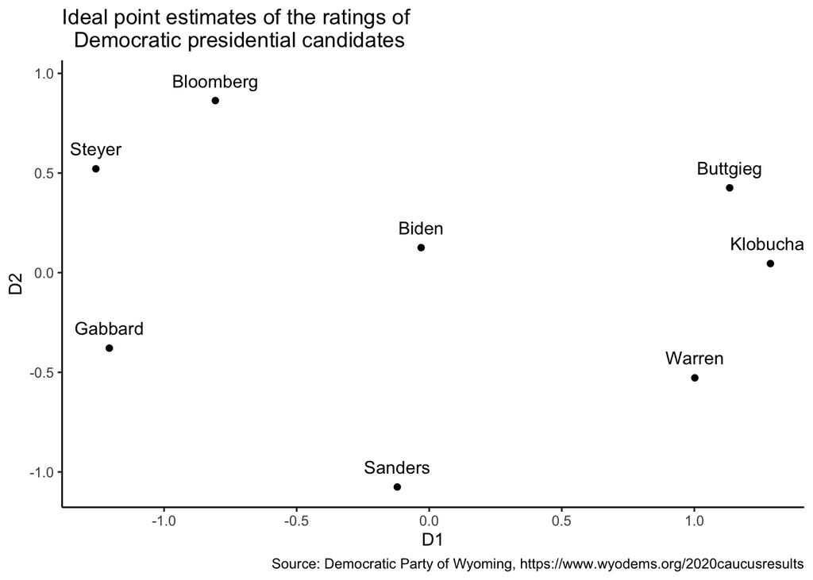

```r
candidate_points<- as.data.frame(wyoming_ideal$conf.col)
ggplot(data = candidate_points,
       mapping = aes(x = D1,
                     y = D2,
                     label = rownames(candidate_points))) +
  geom_point() +
  geom_text(nudge_y = .1) +
  labs(title ="Ideal point estimates of the ratings of
  Democratic presidential candidates",caption = "Source: Democratic Party of Wyoming, https://www.wyodems.org/2020caucusresults") +
  theme_classic()
```

## Visualizing Ideal Points: Voters

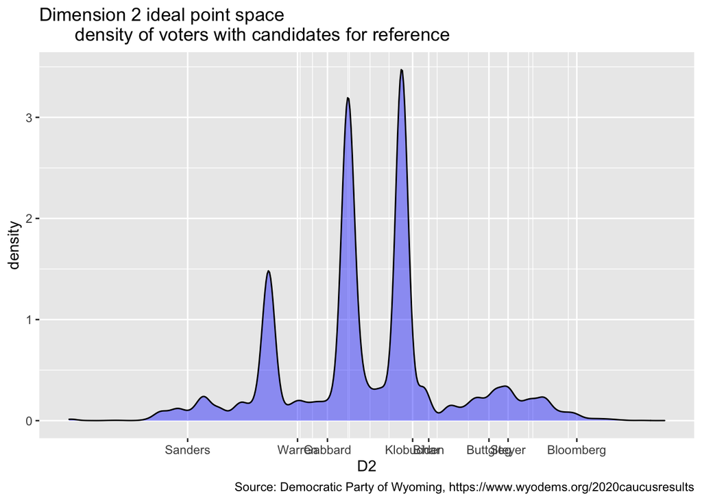

```r
voter_points<-as.data.frame(wyoming_ideal$conf.row)
ggplot(data = voter_points,
       mapping = aes(x = D2))+
  geom_density(fill = "blue", alpha = .4) +
  scale_x_continuous(breaks = candidate_points$D2, labels = rownames(candidate_points)) +
  theme_update(axis.text.x = element_text(angle =45))+
  labs(title ="Dimension 2 ideal point space
       density of voters with candidates for reference",
       caption = "Source: Democratic Party of Wyoming, https://www.wyodems.org/2020caucusresults")
```

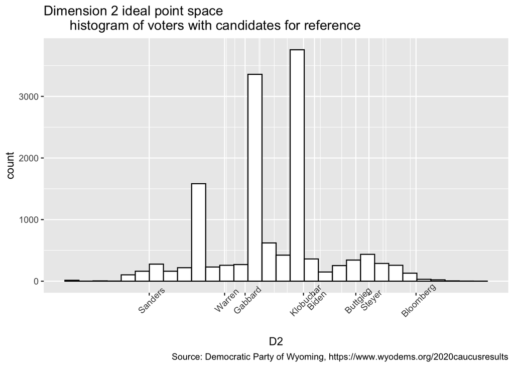

```r
voter_points<-as.data.frame(wyoming_ideal$conf.row)
ggplot(data = voter_points,
       mapping = aes(x = D2))+
  geom_histogram(fill = "white",
                 color = "black") +
  scale_x_continuous(breaks = candidate_points$D2,
                     labels = rownames(candidate_points)) +
  theme_update(axis.text.x = element_text(angle =45)) +
  labs(title ="Dimension 2 ideal point space
       histogram of voters with candidates for reference",
       caption = "Source: Democratic Party of Wyoming, https://www.wyodems.org/2020caucusresults")
```